# Stats 101 Spring 2022 Final

Shanghai Property Report

Anonymous

2/25/2022

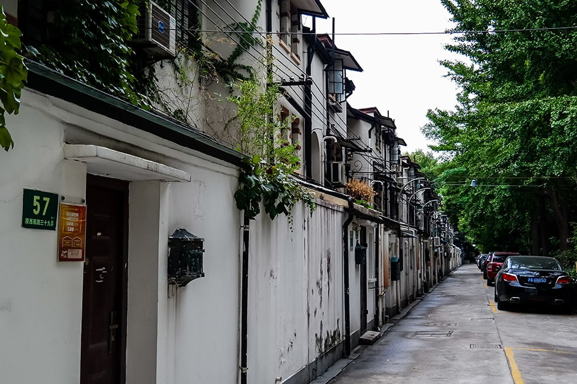

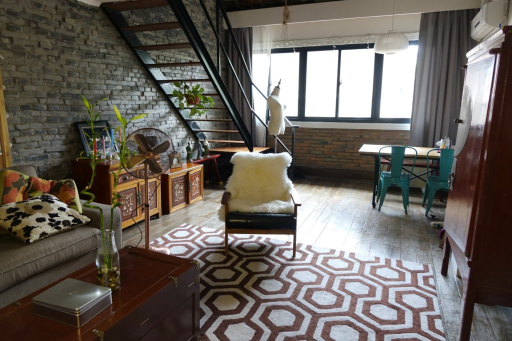

Images of Shanghai Lanehouses[^1]